# An Introduction to Statistical Learning (2013)

Solutions to Exercises

by Brian Hassett

# Chapter 8 Conceptual Exercises

This notebook outlines solutions to the conceptual exercises in Chapter 8 of **An Introduction to Statistical Learning** (James et al. (2013)[^1]).

## Exercise 1

*Draw an example (of your own invention) of a partition of two-dimensional feature space that could result from recursive binary splitting. Your example should contain at least six regions. Draw a decision tree corresponding to this partition. Be sure to label all aspects of your figures, including the regions $R_1$, $R_2$, $\ldots$, the cutpoints $t_1$, $t_2$, $\dots$, and so forth.*

We will use the `Boston` data set from the `MASS` package for this exercise.

Perform a linear regression of the `medv` variable onto all other variables:

```r
lm(medv ~ ., data = Boston) %>%
  broom::tidy()
```

| term | estimate | std.error | statistic | p.value |
| --- | --- | --- | --- | --- |
| (Intercept) | 3.645949e+01 | 5.103458811 | 7.14407419 | 3.283438e-12 |
| crim | -1.080114e-01 | 0.032864994 | -3.28651687 | 1.086810e-03 |
| zn | 4.642046e-02 | 0.013727462 | 3.38157628 | 7.781097e-04 |
| indus | 2.055863e-02 | 0.061495689 | 0.33431004 | 7.382881e-01 |
| chas | 2.686734e+00 | 0.861579756 | 3.11838086 | 1.925030e-03 |
| nox | -1.776661e+01 | 3.819743707 | -4.65125741 | 4.245644e-06 |
| rm | 3.809865e+00 | 0.417925254 | 9.11614020 | 1.979441e-18 |
| age | 6.922246e-04 | 0.013209782 | 0.05240243 | 9.582293e-01 |
| dis | -1.475567e+00 | 0.199454735 | -7.39800360 | 6.013491e-13 |
| rad | 3.060495e-01 | 0.066346440 | 4.61289977 | 5.070529e-06 |

[output cut: 4 more lines]

The variables `dis` and `lstat` are significant in the model. Also, they produce a nice scatter plot (see below). These will be used to generate the diagrams illustrating a partition of two-dimensional feature space and the corresponding decision tree.

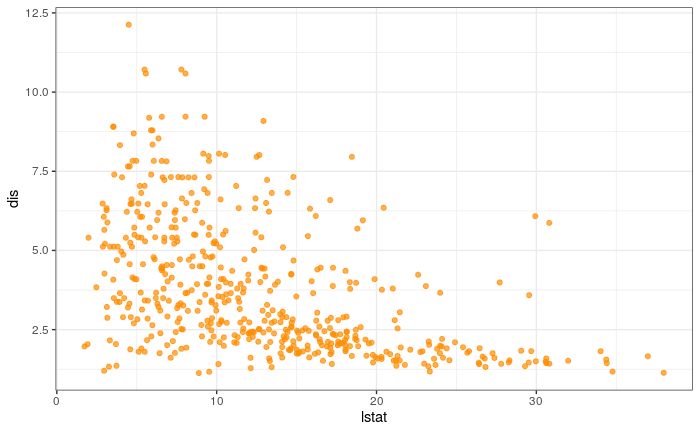

```r
p1 <- ggplot(Boston, aes(lstat, dis)) +
  geom_point(col = "darkorange", alpha = 0.7) +
  theme_bw()
p1
```

Generate a regression tree and prune it to have 6 terminal nodes:

```r
tree1 <- tree(medv ~ dis + lstat, data = Boston)
tree2 <- prune.tree(tree1, best = 6)

# Data frame containing the variables and splits:
tree2_nodes <- data.frame(
  var = tree2$frame$var,
  n = tree2$frame$n,
  dev = tree2$frame$dev,
  yval = tree2$frame$yval,
  splits = tree2$frame$splits
) %>%
  mutate(`cutleft (<)` = parse_number(as.character(splits.cutleft)),
         `cutright (>)` = parse_number(as.character(splits.cutright))) %>%
  dplyr::select(-splits.cutleft, -splits.cutright)
```

Plot a diagram of the tree:

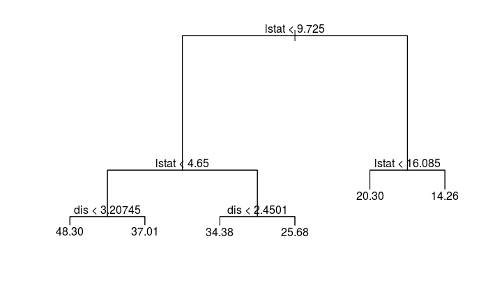

```r
plot(tree2)
text(tree2, pretty = FALSE)
```

Draw the partition of two-dimensional feature space resulting from recursive binary splitting as shown in the above decision tree diagram:

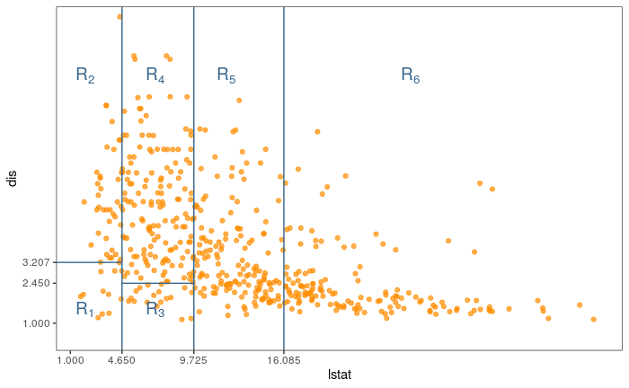

```r
# Regions:
x.int <- tree2_nodes %>%
  filter(var == "lstat") %>%
  dplyr::select(`cutleft (<)`) %>%
  as_vector()
y.int <- tree2_nodes %>%
  filter(var == "dis") %>%
  dplyr::select(`cutleft (<)`) %>%
  as_vector()

# Plot:
color1 <- "steelblue4"
p2 <- p1
for(i in x.int) {
  p2 <- p2 + geom_vline(xintercept = i,
                      color = color1)
}

p2 + geom_line(data = tibble(x = c(0, x.int[2]), y = c(y.int[1])),
              aes(x, y),
              color = color1) +
  geom_line(data = tibble(x = c(x.int[2], x.int[1]), y = c(y.int[2])),
            aes(x, y),
            color = color1) +
  scale_x_continuous(breaks = c(1, unname(x.int)),
                     minor_breaks = NULL,
                     limits = c(0, 40),
                     expand = c(0, 0)) +
  scale_y_continuous(breaks = c(1, unname(round(y.int, 3))),
                     minor_breaks = NULL,
                     limits = c(0, 12.5),
                     expand = c(0, 0)) +
  geom_text(data = data.frame(x = 2, y = 1.5),
            aes(x = x, y = y), label = paste(expression(R[1])),
            size = 5,
            color = color1,
            parse = TRUE) +
  geom_text(data = data.frame(x = 2, y = 10),
            aes(x = x, y = y), label = paste(expression(R[2])),
            size = 5,
            color = color1,
            parse = TRUE) +
  geom_text(data = data.frame(x = 7, y = 1.5),
            aes(x = x, y = y), label = paste(expression(R[3])),
            size = 5,
            color = color1,
            parse = TRUE) +
  geom_text(data = data.frame(x = 7, y = 10),
            aes(x = x, y = y), label = paste(expression(R[4])),
            size = 5,
            color = color1,
            parse = TRUE) +
  geom_text(data = data.frame(x = 12, y = 10),
            aes(x = x, y = y), label = paste(expression(R[5])),
            size = 5,
            color = color1,
            parse = TRUE) +
  geom_text(data = data.frame(x = 25, y = 10),
            aes(x = x, y = y), label = paste(expression(R[6])),
            size = 5,
            color = color1,
            parse = TRUE) +
  theme_bw() +
  theme(panel.grid.major = element_line(size = 0),
        panel.grid.minor = element_line(size = 0))
```

Another example of a partition of two-dimensional feature space is shown in Figure 8.2 of ISLR, which is recreated below:

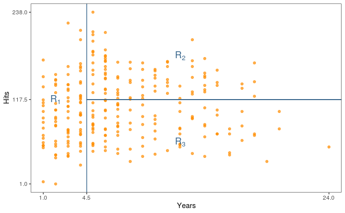

```r
df <- ISLR::Hitters %>%
  filter(!is.na(Salary))

color1 <- "steelblue4"
ggplot(df, aes(Years, Hits)) +
  geom_point(col = "darkorange", alpha = 0.7) +
  geom_vline(xintercept = 4.5,
             color = color1) +
  geom_segment(aes(x = 4.5, xend = 25, y = 117.5, yend = 117.5),
            color = color1) +
  geom_text(data = data.frame(x = 2, y = 117.5),
            aes(x = x, y = y), label = paste(expression(R[1])),
            size = 5,
            color = color1,
            parse = TRUE) +
  geom_text(data = data.frame(x = 12, y = 178),
            aes(x = x, y = y), label = paste(expression(R[2])),
            size = 5,
            color = color1,
            parse = TRUE) +
  geom_text(data = data.frame(x = 12, y = 59),
            aes(x = x, y = y), label = paste(expression(R[3])),
            size = 5,
            color = color1,
            parse = TRUE) +
  scale_x_continuous(breaks = c(1, 4.5, 24),
                     minor_breaks = NULL,
                     limits = c(0, 25),
                     expand = c(0, 0)) +
  scale_y_continuous(breaks = c(1, 117.5, 238),
                     minor_breaks = NULL) +
  theme(plot.background = element_rect(fill = "white"),
        panel.grid.major = element_line(size = 0)) # remove grid lines
```

## Exercise 3

*Consider the Gini index, classification error, and entropy in a simple classification setting with two classes. Create a single plot that displays each of these quantities as a function of $\hat{p}_{m1}$. The x-axis should display $\hat{p}_{m1}$, ranging from $0$ to $1$, and the y-axis should display the value of the Gini index, classification error, and entropy.*

Plot:

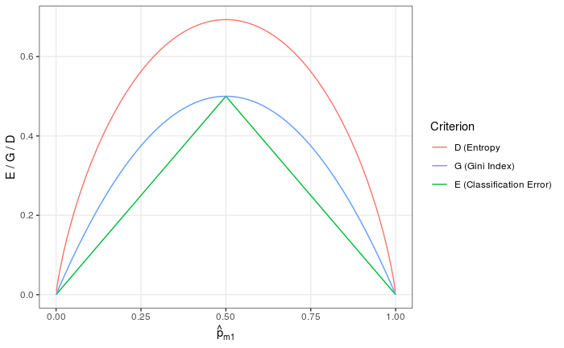

```r
# p.mk
p.m1 <- seq(0, 1, length = 1000)
p.m2 <- 1 - p.m1

# Classification Error:
E <- map2_dbl(p.m1, p.m2, ~(1 -max(.x, .y)))

# Gini Index
G <- p.m1*(1 - p.m1) + p.m2*(1 - p.m2)

# Entropy:
D <- -(p.m1*log(p.m1) + p.m2*log(p.m2))

# Use `gather()` to get the data in long format so a legend can be applied:
df <- tibble(p.m1, E, G, D) %>%
  gather(key = "index", value = "value", E:D)

# Plot:
df %>%
  ggplot(aes(p.m1, value, color = index)) +
    geom_line() +
    labs(x = bquote(hat(p)[m1]),
         y = "E / G / D"
    ) +
    scale_color_discrete(name = "Criterion",
                         breaks = c("D", "G", "E"),
                         labels = c("D (Entropy", "G (Gini Index)", "E (Classification Error)")) +
    theme_bw() +
    theme(panel.grid.minor = element_line(size = 0))
```

## Exercise 4

*This question relates to the plots in Figure 8.12.*

1. *Sketch the tree corresponding to the partition of the predictor space illustrated in the left-hand panel of Figure 8.12. The numbers inside the boxes indicate the mean of $Y$ within each region.*
2. *Create a diagram similar to the left-hand panel of Figure 8.12, using the tree illustrated in the right-hand panel of the same figure. You should divide up the predictor space into the correct regions, and indicate the mean for each region.*

### (a)

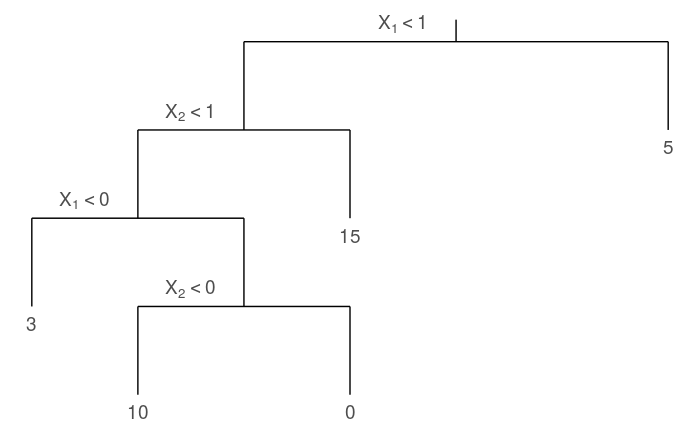

```r
x0 = 0
y0 = 3

ggplot() +
  geom_segment(aes(x = x0, xend = x0, y = y0, yend = y0 + 0.25)) +
  geom_segment(aes(x = x0 - 2, xend = x0 + 2, y = y0, yend = y0)) +
  geom_segment(aes(x = x0 - 2, xend = x0 - 2, y = y0, yend = y0 - 1)) +
  geom_segment(aes(x = x0 - 3, xend = x0 - 1, y = y0 - 1, yend = y0 - 1)) +
  geom_segment(aes(x = x0 - 3, xend = x0 - 3, y = y0 - 1, yend = y0 - 2)) +
  geom_segment(aes(x = x0 - 1, xend = x0 - 1, y = y0 - 1, yend = y0 - 2)) +
  geom_segment(aes(x = x0 - 4, xend = x0 - 2, y = y0 - 2, yend = y0 - 2)) +
  geom_segment(aes(x = x0 - 4, xend = x0 - 4, y = y0 - 2, yend = y0 - 3)) +
  geom_segment(aes(x = x0 - 2, xend = x0 - 2, y = y0 - 2, yend = y0 - 3)) +
  geom_segment(aes(x = x0 - 3, xend = x0 - 3, y = y0 - 3, yend = y0 - 4)) +
  geom_segment(aes(x = x0 - 1, xend = x0 - 1, y = y0 - 3, yend = y0 - 4)) +
  geom_segment(aes(x = x0 - 3, xend = x0 - 1, y = y0 - 3, yend = y0 - 3)) +
  geom_segment(aes(x = x0 + 2, xend = x0 + 2, y = y0, yend = y0 - 1)) +
  geom_text(aes(x = x0 - 0.5, y = y0 + 0.2, label = paste(expression(X[1]), " < 1")),
            size = 5,
            color = "grey30",
            parse = TRUE) +
  geom_text(aes(x = x0 - 2.5, y = y0 - (1 - 0.2), label = paste(expression(X[2]), " < 1")),
            size = 5,
            color = "grey30",
            parse = TRUE) +
  geom_text(aes(x = x0 - 3.5, y = y0 - (2 - 0.2), label = paste(expression(X[1]), " < 0")),
            size = 5,
            color = "grey30",
            parse = TRUE) +
  geom_text(aes(x = x0 - 2.5, y = y0 - (3 - 0.2), label = paste(expression(X[2]), " < 0")),
            size = 5,
            color = "grey30",
            parse = TRUE) +
  geom_text(aes(x = x0 - 4, y = y0 - (3 + 0.2), label = "3"),
            size = 5,
            color = "grey30",
            parse = TRUE) +
  geom_text(aes(x = x0 - 3, y = y0 - (4 + 0.2), label = "10"),
            size = 5,
            color = "grey30",
            parse = TRUE) +
  geom_text(aes(x = x0 - 1, y = y0 - (4 + 0.2), label = "0"),
            size = 5,
            color = "grey30",
            parse = TRUE) +
  geom_text(aes(x = x0 - 1, y = y0 - (2 + 0.2), label = "15"),
            size = 5,
            color = "grey30",
            parse = TRUE) +
  geom_text(aes(x = x0 + 2, y = y0 - (1 + 0.2), label = "5"),
            size = 5,
            color = "grey30",
            parse = TRUE) +
  theme_void()
```

### (b)

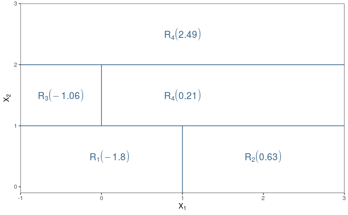

```r
ggplot() +
  geom_hline(yintercept = 1, color = color1) +
  geom_hline(yintercept = 2, color = color1) +
  # geom_hline(yintercept = 0, color = "darkgrey") + # x-axis
  # geom_vline(xintercept = 0, color = "darkgrey") + # y-axis
  geom_segment(aes(x = 1, xend = 1, y = -0.1, yend = 1),
               color = color1) +
  geom_segment(aes(x = 0, xend = 0, y = 1, yend = 2),
               color = color1) +
  geom_text(aes(x = 0.1, y = 0.5, label = paste(expression(R[1]), " (-1.80)")),
          size = 5,
          color = color1,
          parse = TRUE) +
  geom_text(aes(x = 2, y = 0.5, label = paste(expression(R[2]), " (0.63)")),
          size = 5,
          color = color1,
          parse = TRUE) +
  geom_text(aes(x = -0.5, y = 1.5, label = paste(expression(R[3]), " (-1.06)")),
          size = 5,
          color = color1,
          parse = TRUE) +
  geom_text(aes(x = 1, y = 1.5, label = paste(expression(R[4]), " (0.21)")),
          size = 5,
          color = color1,
          parse = TRUE) +
  geom_text(aes(x = 1, y = 2.5, label = paste(expression(R[4]), " (2.49)")),
          size = 5,
          color = color1,
          parse = TRUE) +
  scale_x_continuous(limits = c(-1, 3), expand = c(0, 0)) +
  scale_y_continuous(limits = c(-0.1, 3), expand = c(0, 0)) +
  labs(x = bquote(X[1]), y = bquote(X[2])) +
  theme_bw() +
  theme(panel.grid.minor = element_line(size = 0),
        panel.grid.major = element_line(size = 0))
```

Corresponding tree plot of above diagram:

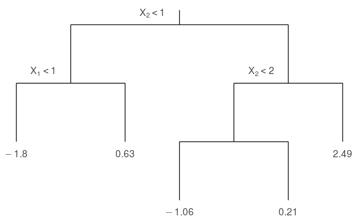

```r
x0 = 0
y0 = 3

ggplot() +
  geom_segment(aes(x = x0, xend = x0, y = y0, yend = y0 + 0.25)) +
  geom_segment(aes(x = x0 - 2, xend = x0 + 2, y = y0, yend = y0)) +
  geom_segment(aes(x = x0 - 2, xend = x0 - 2, y = y0, yend = y0 - 1)) +
  geom_segment(aes(x = x0 - 3, xend = x0 - 1, y = y0 - 1, yend = y0 - 1)) +
  geom_segment(aes(x = x0 - 3, xend = x0 - 3, y = y0 - 1, yend = y0 - 2)) +
  geom_segment(aes(x = x0 - 1, xend = x0 - 1, y = y0 - 1, yend = y0 - 2)) +
  geom_segment(aes(x = x0 + 2, xend = x0 + 2, y = y0, yend = y0 - 1)) +
  geom_segment(aes(x = x0 + 1, xend = x0 + 3, y = y0 - 1, yend = y0 - 1)) +
  geom_segment(aes(x = x0 + 1, xend = x0 + 1, y = y0 - 1, yend = y0 - 2)) +
  geom_segment(aes(x = x0 + 3, xend = x0 + 3, y = y0 - 1, yend = y0 - 2)) +
  geom_segment(aes(x = x0, xend = x0 + 2, y = y0 - 2, yend = y0 - 2)) +
  geom_segment(aes(x = x0, xend = x0, y = y0 - 2, yend = y0 - 3)) +
  geom_segment(aes(x = x0 + 2, xend = x0 + 2, y = y0 - 2, yend = y0 - 3)) +
  geom_text(aes(x = x0 - 0.5, y = y0 + 0.2, label = paste(expression(X[2]), " < 1")),
            size = 5,
            color = "grey30",
            parse = TRUE) +
  geom_text(aes(x = x0 - 2.5, y = y0 - (1 - 0.2), label = paste(expression(X[1]), " < 1")),
            size = 5,
            color = "grey30",
            parse = TRUE) +
  geom_text(aes(x = x0 - 3, y = y0 - (2 + 0.2), label = "-1.80"),
            size = 5,
            color = "grey30",
            parse = TRUE) +
  geom_text(aes(x = x0 - 1, y = y0 - (2 + 0.2), label = "0.63"),
            size = 5,
            color = "grey30",
            parse = TRUE) +
  geom_text(aes(x = x0 + 1.5, y = y0 - (1 - 0.2), label = paste(expression(X[2]), " < 2")),
            size = 5,
            color = "grey30",
            parse = TRUE) +
  geom_text(aes(x = x0, y = y0 - (3 + 0.2), label = "-1.06"),
            size = 5,
            color = "grey30",
            parse = TRUE) +
  geom_text(aes(x = x0 + 2, y = y0 - (3 + 0.2), label = "0.21"),
            size = 5,
            color = "grey30",
            parse = TRUE) +
  geom_text(aes(x = x0 + 3, y = y0 - (2 + 0.2), label = "2.49"),
            size = 5,
            color = "grey30",
            parse = TRUE) +
  theme_void()
```

## Exercise 5

*Suppose we produce ten bootstrapped samples from a data set containing red and green classes. We then apply a classification tree to each bootstrapped sample and, for a specific value of $X$, produce $10$ estimates of $P(\text{Class is Red}|X)$:*
$$0.1, 0.15, 0.2, 0.2, 0.55, 0.6, 0.6, 0.65, 0.7, 0.75.$$
*There are two common ways to combine these results together into a single class prediction. One is the majority vote approach discussed in this chapter. The second approach is to classify based on the average probability. In this example, what is the final classification under each of these two approaches?*

Preliminaries:

```r
# Bootstrap results:
p_red <- c(0.1, 0.15, 0.2, 0.2, 0.55, 0.6, 0.6, 0.65, 0.7, 0.75)

# Returns the mode of a vector:
get_mode <- function(v) {
   uniqv <- unique(v)
   uniqv[which.max(tabulate(match(v, uniqv)))]
}
```

Predictions using the two methods:

```r
# Majority Vote:
p_red %>%
  round() %>%
  get_mode()
```

```
[1] 1
```

```r
# Average:
p_red %>%
  mean() %>%
  round()
```

```
[1] 0
```

The *majority vote* method predicts red (`1`) while the *average probability* method predicts green (`0`).

[^1]: James G, Witten D, Hastie T, Tibshirani R (2013). *An Introduction to Statistical Learning: with Applications in R*. Springer, 1st edition.